# Data summary of my five flux towers

Author

Lucia Digel

Published

Invalid Date

# Github link: https://github.com/LuciaD00/datascience_env_monit

# Data import

```r
library(readr)
library(dplyr)
library(here)
library(lubridate)
library(maps)
library(ggplot2)
library(tidyr)
library(purrr)
library(stringr)

keep <- c("TIMESTAMP_START", "TIMESTAMP_END", "TA_F", "SW_IN_F", "VPD_F", "P_F",
          "NETRAD", "G_F_MDS", "H_F_MDS", "H_F_MDS_QC", "LE_F_MDS", "LE_F_MDS_QC",
          "NEE_VUT_REF", "NEE_VUT_REF_QC", "GPP_NT_VUT_REF", "RECO_NT_VUT_REF")

read_hh <- function(zip_file) {
  # find the half-hourly FLUXMET file inside this zip
  hh_name <- grep("FLUXMET_HH", unzip(zip_file, list = TRUE)$Name, value = TRUE)[1]
  # unzip only that csv
  unzip(zip_file, files = hh_name, exdir = "data/raw/unzipped", overwrite = T)
  # read it
  hh <- read_csv(file.path("data/raw/unzipped", hh_name),
               na = "-9999",
               col_select = any_of(keep),
               col_types = cols(TIMESTAMP_START = "c", TIMESTAMP_END = "c", .default = "d"))
  hh$site <- str_extract(basename(hh_name), "[A-Z]{2}-[A-Za-z0-9]+") # add site id from file name
  return(hh)} # return clean table

zip_files <- list.files(here("data", "raw"), pattern = "\\.zip$", full.names = TRUE)

flux <- map_dfr(zip_files, read_hh) # apply the functiont to each one and combine results
flux <- flux |> mutate(time = as.POSIXct(TIMESTAMP_START, format = "%Y%m%d%H%M", tz = "UTC"))
flux[flux == -9999] <- NA
```

# C1. Site overview

```r
# inspect snapshot
snapshot_file <- list.files(here("data", "snapshots"), pattern = "fluxnet_shuttle_snapshot_.*\\.csv$", full.names = TRUE)[1]
snapshot <- read_csv(snapshot_file)

names(snapshot)
```

```
 [1] "data_hub"               "site_id"                "site_name"
 [4] "location_lat"           "location_long"          "igbp"
 [7] "network"                "team_member_name"       "team_member_role"
[10] "team_member_email"      "first_year"             "last_year"
[13] "download_link"          "fluxnet_product_name"   "product_citation"
[16] "product_id"             "oneflux_code_version"   "product_source_network"
```

```r
site_overview <- snapshot |>
  filter(site_id %in% unique(flux$site)) |>
  select(site_id, site_name, data_hub, igbp, location_lat, location_long,
  first_year, last_year, product_citation) |>
    mutate(country = case_when(
      site_id == "US-Myb" ~ "United States",
      site_id == "CN-Dmn" ~ "China",
      site_id == "CH-Cha" ~ "Switzerland",
      site_id == "FR-Bil" ~ "France",
      site_id == "AU-Cum" ~ "Australia")) |>
    relocate(country, .after = site_name)

site_overview
```

```
# A tibble: 5 × 10
  site_id site_name country data_hub igbp  location_lat location_long first_year
  <chr>   <chr>     <chr>   <chr>    <chr>        <dbl>         <dbl>      <dbl>
1 US-Myb  Mayberry… United… AmeriFl… WET           38.0      -122.          2010
2 FR-Bil  Bilos     France  ICOS     ENF           44.5        -0.956       2014
3 CH-Cha  Chamau    Switze… ICOS     GRA           47.2         8.41        2005
4 CN-Dmn  Daman     China   ICOS     CRO           38.9       100.          2012
5 AU-Cum  Cumberla… Austra… TERN     EBF          -33.6       151.          2014
# ℹ 2 more variables: last_year <dbl>, product_citation <chr>
```

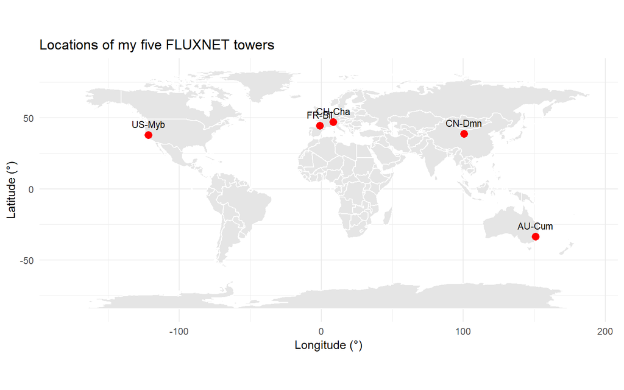

```r
world <- map_data("world")

ggplot() +
    geom_polygon(data = world, aes(x = long, y = lat, group = group), fill = "grey90", colour = "white") +
    geom_point(data = site_overview, aes(x = location_long, y = location_lat), colour = "red", size = 3) +
    geom_text(data = site_overview, aes(x = location_long, y = location_lat, label = site_id), vjust = -1, size = 3) +
    coord_quickmap() +
    labs(x = "Longitude (°)", y = "Latitude (°)", title = "Locations of my five FLUXNET towers") +
    theme_minimal()
```

# C2. Data coverage

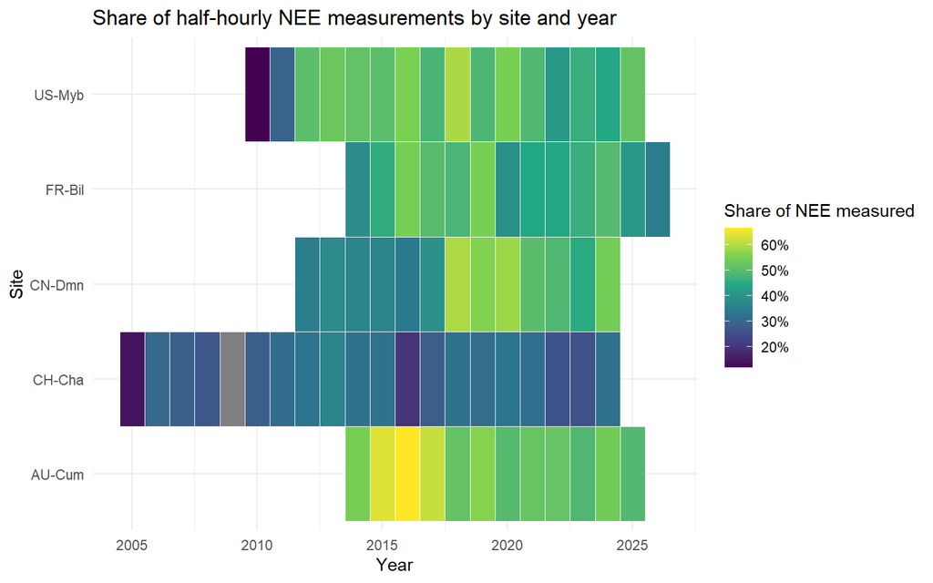

```r
coverage <- flux |>
  mutate(year = year(time)) |>
  group_by(site, year) |>
  summarise(share_measured = mean(NEE_VUT_REF_QC == 0, na.rm = TRUE), .groups = "drop")

ggplot(coverage, aes(x = year, y = site, fill = share_measured)) +
  geom_tile(colour = "white") +
  scale_fill_viridis_c(name = "Share of NEE measured", labels = scales::percent, option = "viridis") +
  labs(x = "Year", y = "Site", title = "Share of half-hourly NEE measurements by site and year") +
  theme_minimal()
```

The best-covered NEE data are generally found in the years 2015-2024. The first year has mostly bad coverage. CH-Cha has the worst NEE data coverage and AU-Cum the best.

# C3. Summary statistics

```r
vars_to_summarize <- c("TA_F", "SW_IN_F", "VPD_F", "P_F", "NEE_VUT_REF",
                       "GPP_NT_VUT_REF", "RECO_NT_VUT_REF", "H_F_MDS", "LE_F_MDS")

units <- c("TA_F" = "°C", "SW_IN_F" = "W m⁻²", "VPD_F" = "kPa", "P_F" = "mm yr⁻¹",
           "NEE_VUT_REF" = "µmol m⁻² s⁻¹", "GPP_NT_VUT_REF" = "µmol m⁻² s⁻¹",
           "RECO_NT_VUT_REF" = "µmol m⁻² s⁻¹", "H_F_MDS" = "W m⁻²", "LE_F_MDS" = "W m⁻²")

summary_table <- flux |>
  select(site, all_of(vars_to_summarize)) |>
  pivot_longer(cols = -site, names_to = "variable", values_to = "value") |>
  filter(variable != "P_F") |> # Exclude P_F here
  group_by(site, variable) |>
  summarise(
    mean = mean(value, na.rm = TRUE),
    min = min(value, na.rm = TRUE),
    max = max(value, na.rm = TRUE),
    perc_missing = mean(is.na(value)) * 100,
    .groups = "drop")

# Precipitation as Mean Annual Sum
precip_stats <- flux |>
  mutate(year = year(time)) |>
  group_by(site, year) |>
  summarise(annual_sum = sum(P_F, na.rm = TRUE), .groups = "drop") |>
  group_by(site) |>
  summarise(
    variable = "P_F",
    mean = mean(annual_sum, na.rm = TRUE),
    min = min(annual_sum, na.rm = TRUE),
    max = max(annual_sum, na.rm = TRUE),
    perc_missing = (sum(is.na(flux$P_F[flux$site == first(site)])) / length(flux$P_F[flux$site == first(site)])) * 100,
    .groups = "drop")

summary_combined <- bind_rows(summary_table, precip_stats)

# create variable_unit column
summary_final <- summary_combined |>
  mutate(variable_unit = paste0(variable, " (", units[variable], ")")) |>
  select(site, variable_unit, mean, min, max, perc_missing)

site_list <- unique(flux$site)
for (s in site_list) {
    cat("\n### Site:", s, "\n")
    print(knitr::kable(summary_final |> filter(site == s) |> select(-site)))}
```

```
### Site: US-Myb


|variable_unit                  |        mean|          min|       max| perc_missing|
|:------------------------------|-----------:|------------:|---------:|------------:|
|GPP_NT_VUT_REF (µmol m⁻² s⁻¹)  |   3.7697428|  -17.7709000|   49.8079|     5.903491|
|H_F_MDS (W m⁻²)                |  14.3359549| -363.4020000|  376.8690|     5.894578|
|LE_F_MDS (W m⁻²)               |  84.8023038| -165.9720000|  867.6750|     5.894578|
|NEE_VUT_REF (µmol m⁻² s⁻¹)     |  -0.7696744|  -37.7460000|   23.0235|     5.903491|
|RECO_NT_VUT_REF (µmol m⁻² s⁻¹) |   3.0000684|    0.0000002|   21.9410|     5.903491|
|SW_IN_F (W m⁻²)                | 233.7580062|    0.0000000| 1278.7900|     0.000000|
|TA_F (°C)                      |  15.5456387|   -4.1230000|   41.4300|     0.000000|
|VPD_F (kPa)                    |   7.2670232|    0.0060000|   62.3490|     0.000000|
|P_F (mm yr⁻¹)                  | 263.8740625|   78.2110000|  379.7430|     0.000000|

### Site: CN-Dmn


|variable_unit                  |        mean|       min|       max| perc_missing|
|:------------------------------|-----------:|---------:|---------:|------------:|
|GPP_NT_VUT_REF (µmol m⁻² s⁻¹)  |    3.550369|  -42.7978|   79.4375|     2.725135|
|H_F_MDS (W m⁻²)                |   21.355569| -129.4590|  360.3280|     2.722503|
|LE_F_MDS (W m⁻²)               |   55.257016| -150.6570|  993.7160|     2.722503|
|NEE_VUT_REF (µmol m⁻² s⁻¹)     |   -1.849248|  -77.7389|   45.5772|     2.725135|
|RECO_NT_VUT_REF (µmol m⁻² s⁻¹) |    1.713610|    0.0000|   13.9344|     2.725135|
|SW_IN_F (W m⁻²)                |  175.133589|    0.0000| 1105.7800|     0.000000|
|TA_F (°C)                      |    7.763607|  -34.1830|   36.6770|     0.000000|
|VPD_F (kPa)                    |    7.148557|    0.0000|   49.6520|     0.000000|
|P_F (mm yr⁻¹)                  | 1441.322769| 1234.6600| 1714.1480|     0.000000|

### Site: CH-Cha


|variable_unit                  |         mean|       min|       max| perc_missing|
|:------------------------------|------------:|---------:|---------:|------------:|
|GPP_NT_VUT_REF (µmol m⁻² s⁻¹)  |    6.8904989|  -47.9270|   95.8841|     7.604095|
|H_F_MDS (W m⁻²)                |   10.1879945| -298.1560|  998.9870|     7.592973|
|LE_F_MDS (W m⁻²)               |   47.4110987| -295.8330|  974.3530|     7.603810|
|NEE_VUT_REF (µmol m⁻² s⁻¹)     |    0.0935083|  -79.6029|   49.9766|     7.604095|
|RECO_NT_VUT_REF (µmol m⁻² s⁻¹) |    6.9840072|    0.0000|   43.9202|     7.604095|
```

[output cut: 19 more lines]

```

### Site: AU-Cum


|variable_unit                  |        mean|         min|       max| perc_missing|
|:------------------------------|-----------:|-----------:|---------:|------------:|
|GPP_NT_VUT_REF (µmol m⁻² s⁻¹)  |   5.0975744|  -44.415000|   82.8896|            0|
|H_F_MDS (W m⁻²)                |  43.5803049| -237.000000|  796.0000|            0|
|LE_F_MDS (W m⁻²)               |  55.3113460|  -88.000000|  792.0000|            0|
|NEE_VUT_REF (µmol m⁻² s⁻¹)     |  -0.9061445|  -78.526500|   49.7804|            0|
|RECO_NT_VUT_REF (µmol m⁻² s⁻¹) |   4.1856435|    0.490394|   16.5339|            0|
|SW_IN_F (W m⁻²)                | 190.7125012|    0.000000| 1384.0000|            0|
|TA_F (°C)                      |  18.3154428|   -1.800000|   46.3200|            0|
|VPD_F (kPa)                    |   8.2081305|    0.000000|   89.7030|            0|
|P_F (mm yr⁻¹)                  | 929.4400000|  567.600000| 1476.2000|            0|
```

# C4. Time series

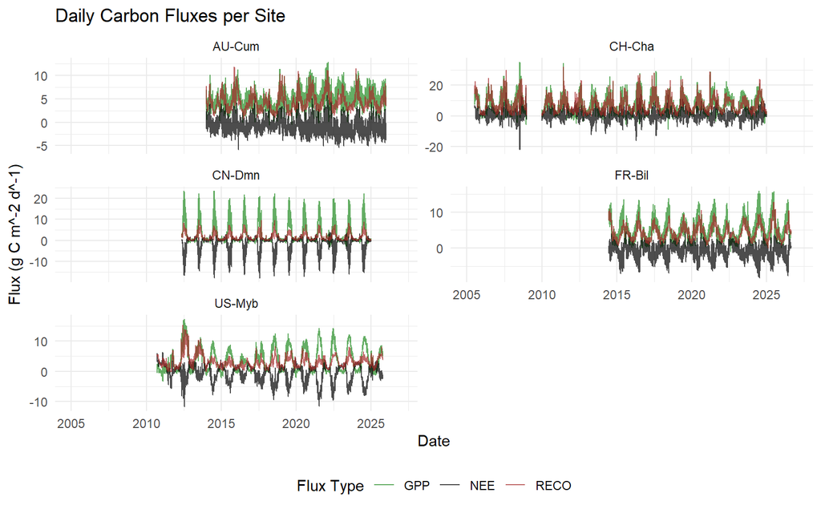

```r
# half-hourly data to daily values
daily_flux <- flux |>
  mutate(date = as_date(time)) |>
  group_by(site, date) |>
  summarise(
    NEE = mean(NEE_VUT_REF, na.rm = TRUE),
    GPP = mean(GPP_NT_VUT_REF, na.rm = TRUE),
    RECO = mean(RECO_NT_VUT_REF, na.rm = TRUE),
    .groups = "drop")

conv_factor <- 1.0378

daily_flux_conv <- daily_flux |>
  mutate(across(c(NEE, GPP, RECO), ~ .x * conv_factor))

plot_data <- daily_flux_conv |>
  pivot_longer(cols = c(NEE, GPP, RECO),
               names_to = "Flux_Type",
               values_to = "Value")

ggplot(plot_data, aes(x = date, y = Value, color = Flux_Type)) +
  geom_line(alpha = 0.7) +
  facet_wrap(~site, ncol = 2, scales = "free_y") +
  scale_color_manual(values = c("GPP" = "forestgreen", "RECO" = "brown", "NEE" = "black")) +
  labs(
    title = "Daily Carbon Fluxes per Site",
    x = "Date",
    y = expression("Flux (g C m^-2 d^-1)"),
    color = "Flux Type") +
  theme_minimal() +
  theme(legend.position = "bottom")
```

# C5. Diurnal cycles

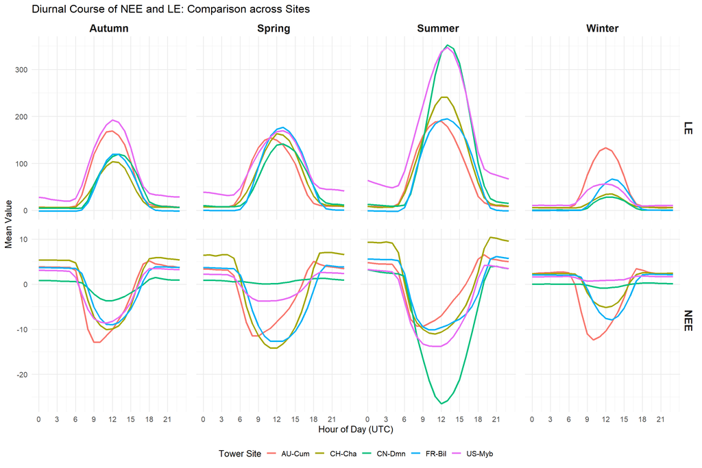

```r
# Join latitude info to the flux data for hemisphere
flux_with_lat <- flux |>
  left_join(site_overview |> select(site_id, location_lat), by = c("site" = "site_id"))

# Hour and Month variables
flux_with_time <- flux_with_lat |>
  mutate(hour = hour(time), month = month(time))

# Define seasons based on hemisphere and month
# Northern: DJF=Winter, MAM=Spring, JJA=Summer, SON=Autumn
# Southern: DJF=Summer, MAM=Autumn, JJA=Winter, SON=Spring
flux_with_seasons <- flux_with_time |>
  mutate(season = case_when(
    location_lat >= 0 & month %in% c(12, 1, 2) ~ "Winter",
    location_lat >= 0 & month %in% c(3, 4, 5)  ~ "Spring",
    location_lat >= 0 & month %in% c(6, 7, 8)  ~ "Summer",
    location_lat >= 0 & month %in% c(9, 10, 11) ~ "Autumn",
    location_lat < 0  & month %in% c(12, 1, 2) ~ "Summer",
    location_lat < 0  & month %in% c(3, 4, 5)  ~ "Autumn",
    location_lat < 0  & month %in% c(6, 7, 8)  ~ "Winter",
    location_lat < 0  & month %in% c(9, 10, 11) ~ "Spring"))

diurnal_summary <- flux_with_seasons |>
  group_by(site, season, hour) |>
  summarise(NEE = mean(NEE_VUT_REF, na.rm = TRUE), LE = mean(LE_F_MDS, na.rm = TRUE), .groups = "drop") |>
  pivot_longer(cols = c(NEE, LE), names_to = "Variable", values_to = "Value")

ggplot(diurnal_summary, aes(x = hour, y = Value, color = site)) +
  geom_line(linewidth = 1.2) +
  facet_grid(Variable ~ season, scales = "free_y") +
  labs(title = "Diurnal Course of NEE and LE: Comparison across Sites", x = "Hour of Day (UTC)", y = "Mean Value",
    color = "Tower Site") +
  scale_x_continuous(breaks = seq(0, 23, 3)) +
  theme_minimal(base_size = 14) +
  theme(legend.position = "bottom", strip.text = element_text(size = 16, face = "bold"),
  panel.spacing = unit(1, "lines"))
```

To determine the seasons, I used the latitude of each tower. For sites in the Northern Hemisphere (latitude ≥0), I assigned December, January, and February as Winter. For the site in the Southern Hemisphere (latitude <0), I reversed the seasonal assignment, designating December, January, and February as Summer. The diurnal cycles were then calculated by averaging all observations for each hour of the day across the respective seasons.

# C6. Your reading (energy balance)

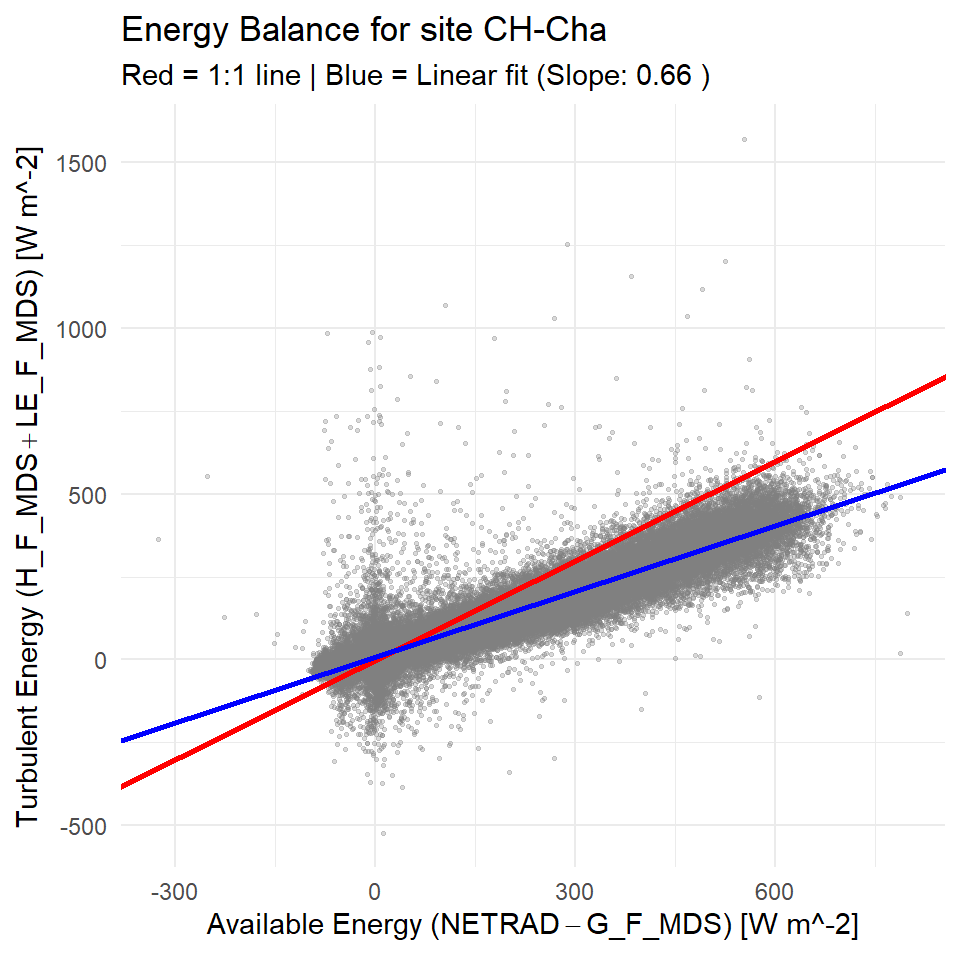

```r
# Find a site that has both NETRAD and G_F_MDS (check for fewest NAs for these variables)
energy_check <- flux |>
  group_by(site) |>
  summarise(valid_data = sum(!is.na(NETRAD) & !is.na(G_F_MDS))) |>
  arrange(desc(valid_data))

best_site <- energy_check$site[1] # pick site with the most data

# prepare data for scatter plot
eb_data <- flux |>
  filter(site == best_site) |>
  filter(H_F_MDS_QC == 0 & LE_F_MDS_QC == 0) |> # only measured H and LE
  mutate(available_energy = NETRAD - G_F_MDS, turbulent_energy = H_F_MDS + LE_F_MDS) |>
  filter(!is.na(available_energy), !is.na(turbulent_energy))

# linear fit for the slope
fit <- lm(turbulent_energy ~ available_energy, data = eb_data)
slope_val <- round(coef(fit)[2], 3)

ggplot(eb_data, aes(x = available_energy, y = turbulent_energy)) +
  geom_point(alpha = 0.3, size = 0.5, color = "grey50") +
  geom_abline(intercept = 0, slope = 1, color = "red", linewidth = 1) + # 1:1 line
  geom_abline(intercept = coef(fit)[1], slope = coef(fit)[2], color = "blue", linewidth = 1) +
  labs(title = paste("Energy Balance for site", best_site),
    subtitle = paste("Red = 1:1 line | Blue = Linear fit (Slope:", slope_val, ")"),
    x = expression("Available Energy (NETRAD" - "G_F_MDS) [W m^-2]"),
    y = expression("Turbulent Energy (H_F_MDS" + "LE_F_MDS) [W m^-2]")) +
  theme_minimal()
```

# Data and citation

**Site Citations:** Jaclyn Hatala Matthes, Cove Sturtevant, Patty Oikawa, Samuel D Chamberlain, Daphne Szutu, Ariane Arias-Ortiz, Joseph Verfaillie, Dennis Baldocchi (2026), AmeriFlux FLUXNET-1F US-Myb Mayberry Wetland, Ver. v1.3_r1 (2010-2025), AmeriFlux AMP, (Dataset). https://doi.org/10.17190/AMF/1871139

Domec, J.C., Loustau, D., Aluome, C., Chipeaux, C., Denou, J.-L., Depuydt, J., Garrigou, C., Kruszewski, A., Lafont, S. (2026). Fluxnet Archive Product from Bilos, 2014-01-01–2026-09-06, FLUXNET, https://hdl.handle.net/11676/7T6UyUOXgB0j4LrWbPhTMu2P

Buchmann, N., Hortnagl, L., Feigenwinter, I., Wang, Y., Zeeman, M., Merbold, L., Merbold, L., Fuchs, K., Baur, T., Meier, P. (2026). Fluxnet Archive Product from Chamau, 2005–2024, FLUXNET, https://hdl.handle.net/11676/_BRGI6F0aH0BpH6M9QscIcym

Liu, S., Che, T., Xu, Z. (2026). Fluxnet Archive Product from Daman, 2012–2024, FLUXNET, https://hdl.handle.net/11676/rDvBU2EyWJDrd8bxJoMF69Lt

Pendall, E., Griebel, A., Barton, C., Metzen, D. (2026): Cumberland Plain FLUXNET Release 2026_r1. Version 2026_r1. Terrestrial Ecosystem Research Network (TERN). (Dataset).

**General Citations:** Pastorello et al. (2020), Scientific Data 7, 225, https://doi.org/10.1038/s41597-020-0534-3

**Acknowledgement:** FLUXNET data products were produced and harmonized by eddy covariance regional networks and data processing centers, including AmeriFlux, ChinaFlux, European Fluxes Database, ICOS, JapanFlux, KoFlux, OzFlux, SAEON, and TERN. These products also include a modified version of ERA5 hourly data provided by the Copernicus Climate Change Service.